# jekyll-jupyter-notebook20260215-12328-b5x7lk

## Source Information

**Author**: Bob Sinkovits

**Last Updated Date**: October 01, 2024

**Resources**: https://github.com/sinkovit/PythonSeries

## Goal

This Jupyter notebook demonstrates how to use the Dask library for parallel processing, specifically focusing on visualizing the task graphs (DAGs) that Dask creates to efficiently manage dependencies and computation on chunked data.

# Dask Graphs

The key element of `dask` is the scheduler which builds a Direct Acyclic Graph of all the operations to be executed on each chunk of data to compute the final result.

The DAG is the key feature that allows `dask` to understand the dependency graph between all the steps in a set of computations and parallelize accordingly.

## Required Modules for the Jupyter Notebook

Before running the notebook, make sure to load the following modules.

**Module: dask**

```python
import dask.array as da
```

## Creating a Dask Array

```python
x = da.ones(15, chunks=(5,))
```

The following command creates a Dask array with 15 elements, divided into chunks of 5. As a result, the array will be split into 3 chunks. Each chunk will be processed independently, allowing for efficient parallel computation.

`visualize()` calls `graphviz` to create a graphical representation of the graph

## Visualizing the Computation Graph:

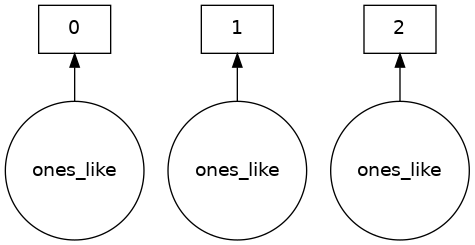

```python
x.visualize()
```

Then, lets create a new Dask array by adding 1 to each element of the Dask array x.

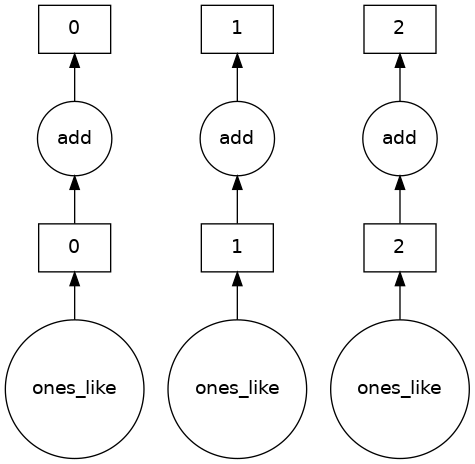

```python
(x+1).visualize()
```

After adding 1 to each element of x, the sum() method is called to compute the sum of all elements in the resulting Dask array.

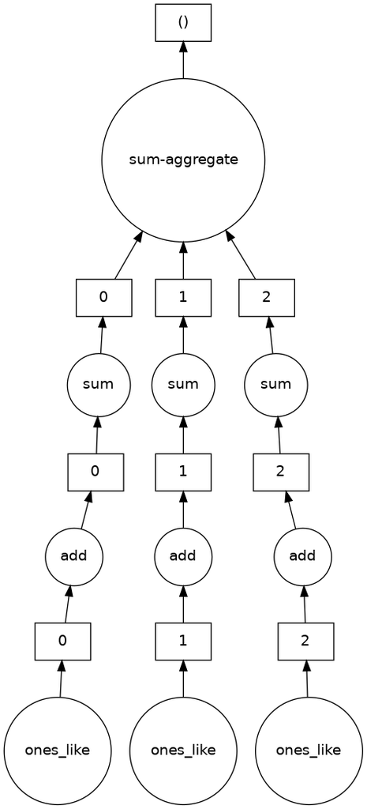

```python
(x+1).sum().visualize()
```

Let's try with a more complex example.

```python
m = da.ones((15, 15), chunks=(5,5))
```

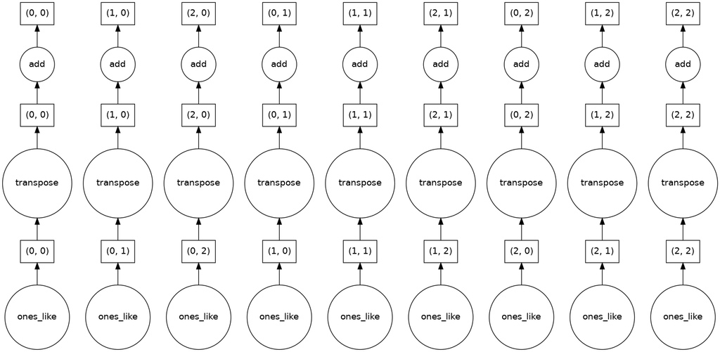

```python
(m.T + 1).visualize()
```

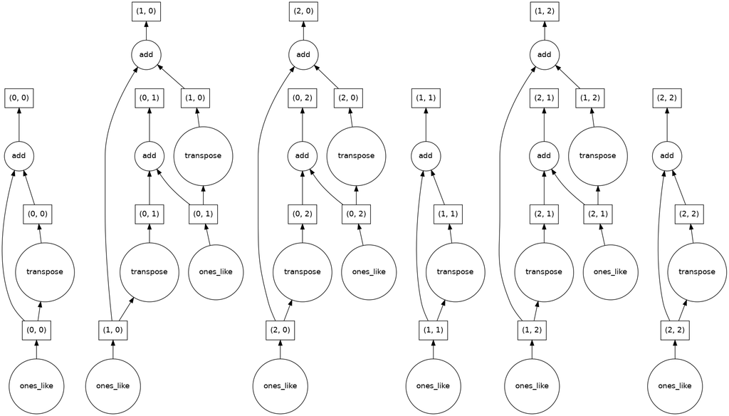

```python
(m.T + m).visualize()
```

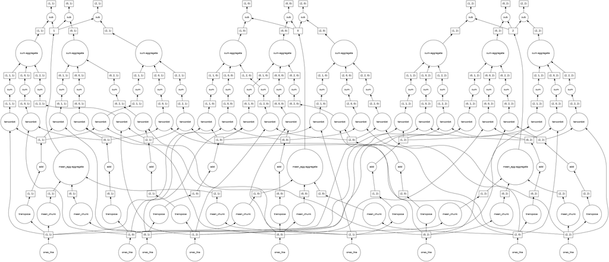

```python
(m.dot(m.T + 1) - m.mean(axis=0)).visualize()
```

```python
(m.dot(m.T + 1) - m.mean(axis=0)).compute()
```

```
array([[29., 29., 29., 29., 29., 29., 29., 29., 29., 29., 29., 29., 29.,
        29., 29.],
       [29., 29., 29., 29., 29., 29., 29., 29., 29., 29., 29., 29., 29.,
        29., 29.],
       [29., 29., 29., 29., 29., 29., 29., 29., 29., 29., 29., 29., 29.,
        29., 29.],
       [29., 29., 29., 29., 29., 29., 29., 29., 29., 29., 29., 29., 29.,
        29., 29.],
       [29., 29., 29., 29., 29., 29., 29., 29., 29., 29., 29., 29., 29.,
        29., 29.],
       [29., 29., 29., 29., 29., 29., 29., 29., 29., 29., 29., 29., 29.,
        29., 29.],
       [29., 29., 29., 29., 29., 29., 29., 29., 29., 29., 29., 29., 29.,
        29., 29.],
       [29., 29., 29., 29., 29., 29., 29., 29., 29., 29., 29., 29., 29.,
        29., 29.],
       [29., 29., 29., 29., 29., 29., 29., 29., 29., 29., 29., 29., 29.,
        29., 29.],
       [29., 29., 29., 29., 29., 29., 29., 29., 29., 29., 29., 29., 29.,
        29., 29.],
       [29., 29., 29., 29., 29., 29., 29., 29., 29., 29., 29., 29., 29.,
        29., 29.],
       [29., 29., 29., 29., 29., 29., 29., 29., 29., 29., 29., 29., 29.,
        29., 29.],
       [29., 29., 29., 29., 29., 29., 29., 29., 29., 29., 29., 29., 29.,
        29., 29.],
       [29., 29., 29., 29., 29., 29., 29., 29., 29., 29., 29., 29., 29.,
        29., 29.],
       [29., 29., 29., 29., 29., 29., 29., 29., 29., 29., 29., 29., 29.,
        29., 29.]])
```

## Submit Ticket

If you find anything that needs to be changed, edited, or if you would like to provide feedback or contribute to the notebook, please submit a ticket by contacting us at:

Email: consult@sdsc.edu

We appreciate your input and will review your suggestions promptly!